# unPC_tutorial

Geoffrey House

April 16, 2017

Let’s see how to make a simple un-PC output, and we’ll work through the details of the different options a little later.

We’ll start by making aggregate plots using the 10 PCA output files found in the exampleData directory. Each of these output files is the PCA results for a different iteration of the *ms* simulation using the migration barrier scenario. These aggregate plots are then made by averaging the *un-PC* value for each population pair across the 10 iterations to get the aggregated *un-PC* value for that population pair, which is then plotted.

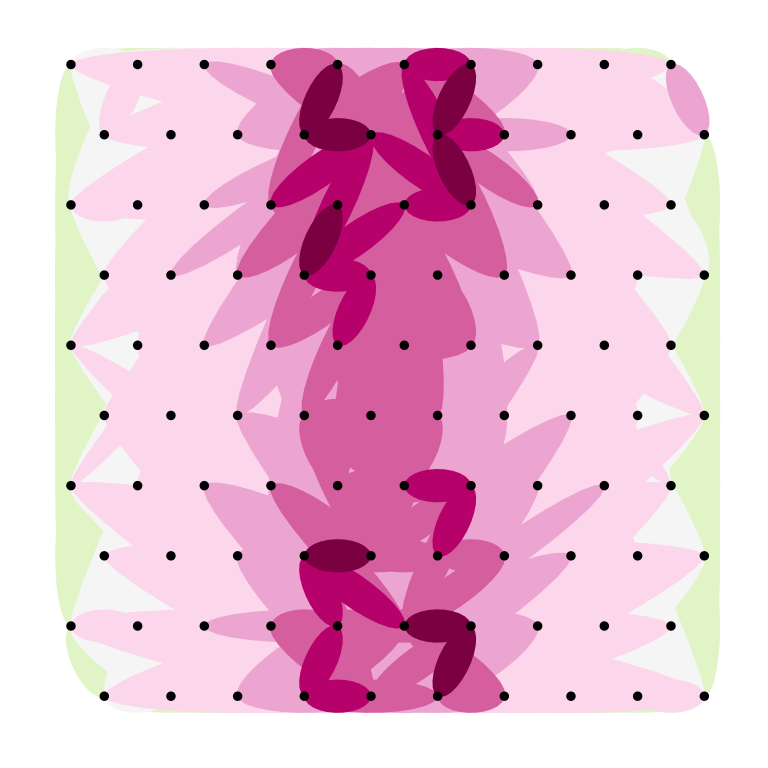

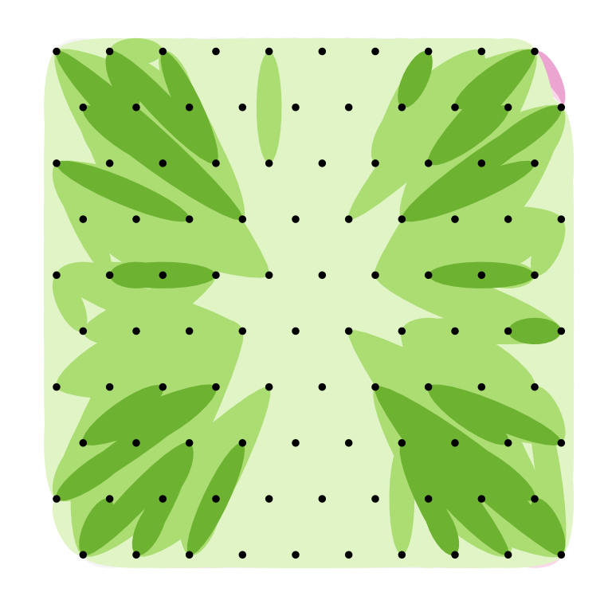

```r
unPC::unPC(inputToProcess = "~/Box Sync/R_code/unPC/exampleData", geogrCoords = "~/Box Sync/R_code/unPC/exampleData/populationCoordinates_DCTTransformed.txt", geogrCoordsForPlotting = "~/Box Sync/R_code/unPC/exampleData/populationCoordinates_NOT_DCTTransformed.txt", populationPointNormalization = 10, savePlotsToPdf = FALSE)
```

On the left is the plot with the most differentiated ellipses (population pairs with the highest *un-PC* scores) on top, and on the right is the plot with the least differentiated ellipses (population pairs with the lowest *un-PC* scores) on top.

If we want to change the color scheme, that is easy to do by supplying any valid RColorBrewer color scheme (for a list of valid color schemes type `RColorBrewer::brewer.pal.info`.) Let’s change it to the “RdYlBu” color scheme:

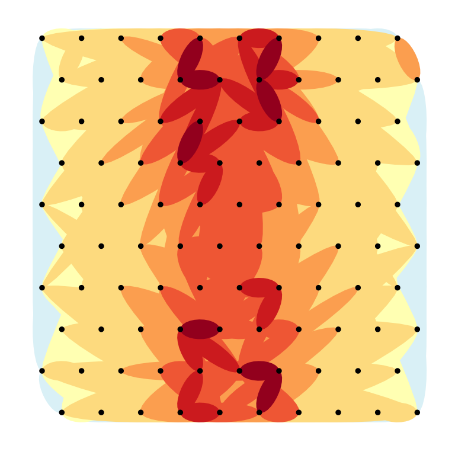

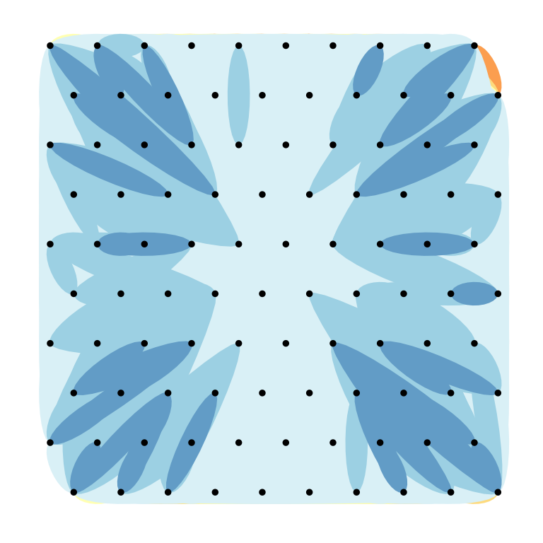

```r
unPC::unPC(inputToProcess = "~/Box Sync/R_code/unPC/exampleData", geogrCoords = "~/Box Sync/R_code/unPC/exampleData/populationCoordinates_DCTTransformed.txt", geogrCoordsForPlotting = "~/Box Sync/R_code/unPC/exampleData/populationCoordinates_NOT_DCTTransformed.txt", populationPointNormalization = 10, colorBrewerPalette = "RdYlBu", savePlotsToPdf = FALSE)
```